# termiteN

Tristan Caro

11/24/2020

# Termites

Many non-biological and biological processes create regularly patterned landscapes. However, there is not much understanding of how patterning impacts ecological behavior.

Spatial structure in biotic processes is an important factor in governing community-level interactions and ecosystem processes. In many cases, a keystone species exerts community-wide effects. Often, this effect is created through indirect interactions that are mediated through an abiotic system or process.

Termites have been identified as a keystone species in the African savannas. Termites are particularly interesting due to their ability to farm fungi.

Legumes, like *Acacia*, access atmospheric $N_2$ by cultivating symbiotic relationships with nitrogen-fixing bacteria. This can be an important input of N into N-limited ecosystems. Although levels of N fixation vary amongst species and across topoedaphic and cliatic gradients, the *Acacia* tree’s ability to collect large quantities of N from fixation allows them to thrive in N-depleted soils. This is in contrast to *Aerva*, a non-N fixing tree also found in the African savannah.

Nitrogen isotope $\delta ^{15}N$ values measured in plant tissues can provide insight into the relative contributions of N sources (fixed N vs. soil N).

Legumes obtain their N from the soil and through symbiotic N2 fixation. These two N sources often differ in 15N abundance whereby an N-fixing plant, which depends on both soil N and symbiotic N2 fixation, is less abundant in 15N than a non-N2-fixing plant grown at the same site (Danso etal., 1993; Evans, 2001; Handley and Scrimgeour, 1997; Shearer and Kohl, 1986). Plants dependent on soil N have positive d15N values that are close to those of soil nitrogen. In N-fixing plants, significant amounts of N are derived from the atmosphere and therefore dilute the d15N concentration derived from the soil.

## Grazing Behavior Model - Brief Summary

The directory `TeamTermite` is a git submodule that contains an agent-based model of herbivore grazing amid nutrient rich hotspots, representing termite mounds.

The model has three phases:

1. The landscape is initialized in either a `uniform`, `neutral`, or `random` patterning:
   - A uniform landscape contains regularly spaced termite mounds.
   - A random landscape contains termite mounds that are randomly scattered.
   - A neutral landscape contains no termite mounds but instead stochastically distributes nutrition across the space.
2. Agents are instantiated:
   - An agent, representing an herbivore, is spawned into the landscape.
   - The agent begins a random walk whose parameters are user-defined.
   - The agent grazes on food it encounters.
   - The agent utilizes a `memory` method, which allows it to remember areas of higher food concentration.
   - The agent exits the landscape.
   - Another agent is spawned.
3. Simulation data is exported:
   - Landscape data, such as the amount and quality of food, is exported as a `.csv` array.
   - Agent data, such as trajectory and residence time, is exported as a `.csv` array.

# Visualizing Landscape Change with 3D Plotting

```python
import numpy as np
from numpy import genfromtxt
import matplotlib.pyplot as plt
print("Libraries are loaded.")
```

```
## Libraries are loaded.
```

We can use `genfromtxt` to read our csv as a numpy array:

```python
uni_landscape_end = genfromtxt('TeamTermite/dfs/degrades_uniform/uniform_200_500_quantity_end.csv', delimiter=",")
uni_landscape_start = genfromtxt('TeamTermite/dfs/degrades_uniform/uniform_200_500_quantity_start.csv', delimiter=",")
uni_landscape_start
```

```
## array([[20., 20., 20., ..., 20., 20., 20.],
##        [20., 20., 20., ..., 20., 20., 20.],
##        [20., 20., 20., ..., 20., 20., 20.],
##        ...,
##        [20., 20., 20., ..., 20., 20., 20.],
##        [20., 20., 20., ..., 20., 20., 20.],
##        [20., 20., 20., ..., 20., 20., 20.]])
```

We can define a function to create a 2d heatmap that shows the location of termite mounds and the relative amount of food on such mounds. The below plot is an example of the “start” of a simulation where termite mounds are rich in food, and mounds are evenly spaced.

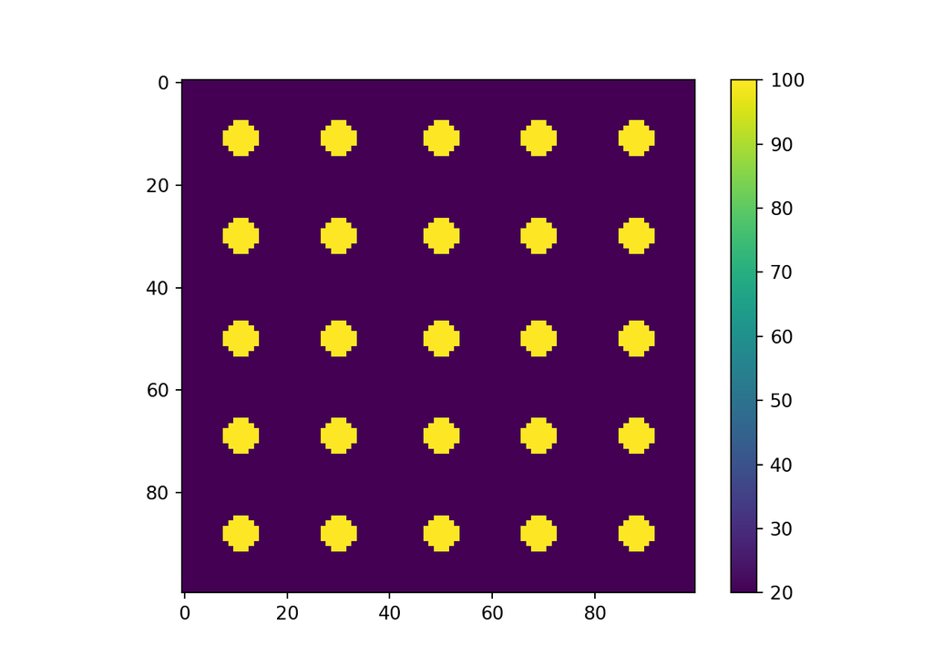

```python
def heatmap2d(arr: np.ndarray):
    plt.imshow(arr, cmap='viridis')
    plt.colorbar()
    plt.show()

heatmap2d(uni_landscape_start)
```

```python
def surface3d(arr: np.ndarray):
    ny, nx = arr.shape
    xd = np.linspace(0, 1, nx)
    yd = np.linspace(0, 1, ny)
    xv, yv = np.meshgrid(xd, yd)
    fig = plt.figure()
    ax = fig.add_subplot(111, projection = '3d')
    ax.plot_surface(xv, yv, arr, cmap = 'viridis')
    plt.show()
```

Here is the landscape after herbivores have passed through and eaten. Note the decreased food concentrations on termite mounds. This is due to the grazing behavior of the agents in our initial model.

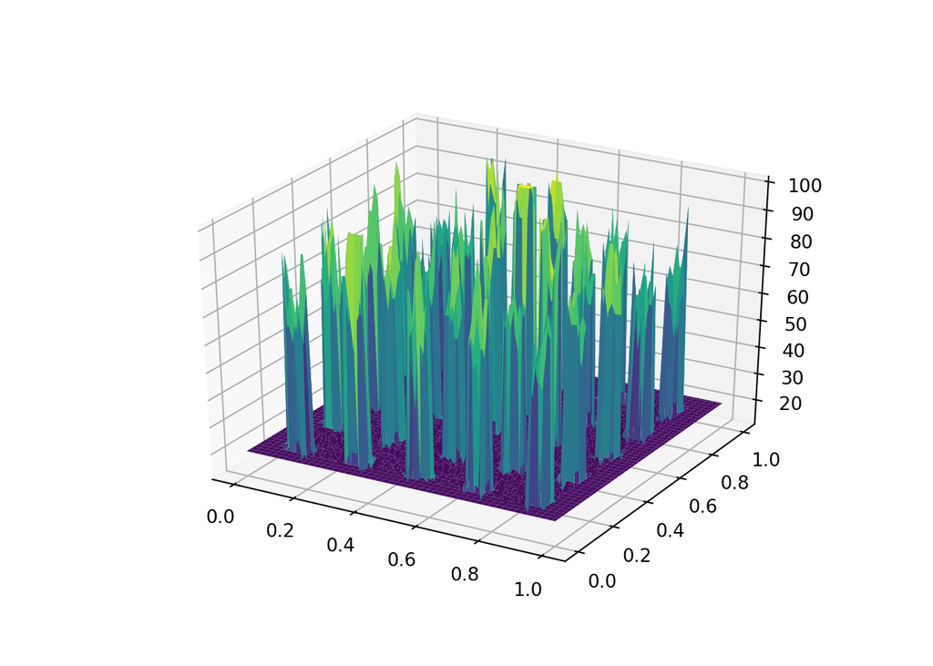

```python
surface3d(uni_landscape_end)
```

```python
combined_uni = list([np.ndarray.flatten(uni_landscape_start), np.ndarray.flatten(uni_landscape_end)])

fig1, ax1 = plt.subplots()
ax1.violinplot(combined_uni)
```

```
## {'bodies': [<matplotlib.collections.PolyCollection object at 0x11a6f29e8>, <matplotlib.collections.PolyCollection object at 0x11a6f2cf8>], 'cmaxes': <matplotlib.collections.LineCollection object at 0x10c65e550>, 'cmins': <matplotlib.collections.LineCollection object at 0x11a6f2b00>, 'cbars': <mat…
```

```python
ax1.set_title('Plant Population Density')
ax1.set_ylabel('Plant Matter (value per square)')
ax1.set_xticks([1,2])
ax1.set_xticklabels(['Before Grazing', 'After Grazing'])
```

```
## [Text(0, 0, 'Before Grazing'), Text(0, 0, 'After Grazing')]
```

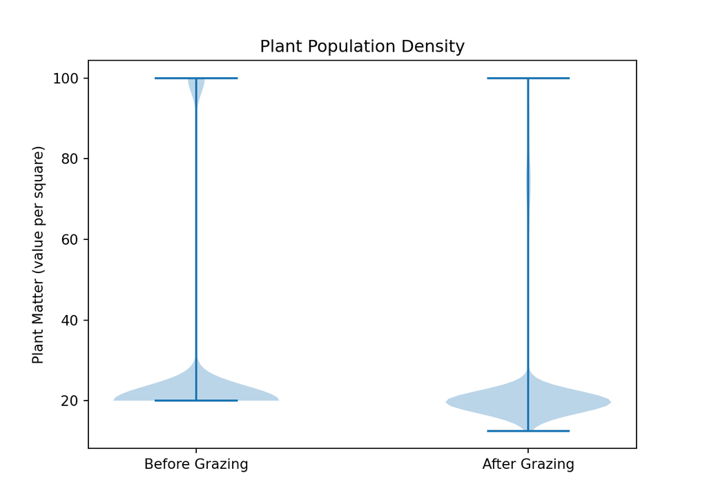

```python
plt.show()
```

# Creating an Isoscape

The simplest scenario to consider is that the termite mounds all adopt the maximum $\delta^{15}N$ values reflecting measured *Acacia* leaf samples. Correspondingly, the space between the termite mounds all adopt the minimum *Acacia* leaf $\delta^{15}N$ values.

$\delta^{15}N$ Acacia on Mound = + 4‰ $\delta^{15}N$ Acacia off Mound = + 0.5‰.

We can now convert our landscapes to isoscapes by assigning these values based on the food concentration at the start of the simulation.

```python
d15_uni_start = uni_landscape_start.copy()
d15_uni_start[d15_uni_start == 100] = 4 # delta 15N in permil
d15_uni_start[d15_uni_start == 20] = 0.5 # delta 15N in permil

d15_uni_end = uni_landscape_start.copy()
d15_uni_end[d15_uni_end == 100] = 4 # delta 15N in permil
d15_uni_end[d15_uni_end == 20] = 0.5 # delta 15N in permil
```

View the beginning of the simulation as an isoscape:

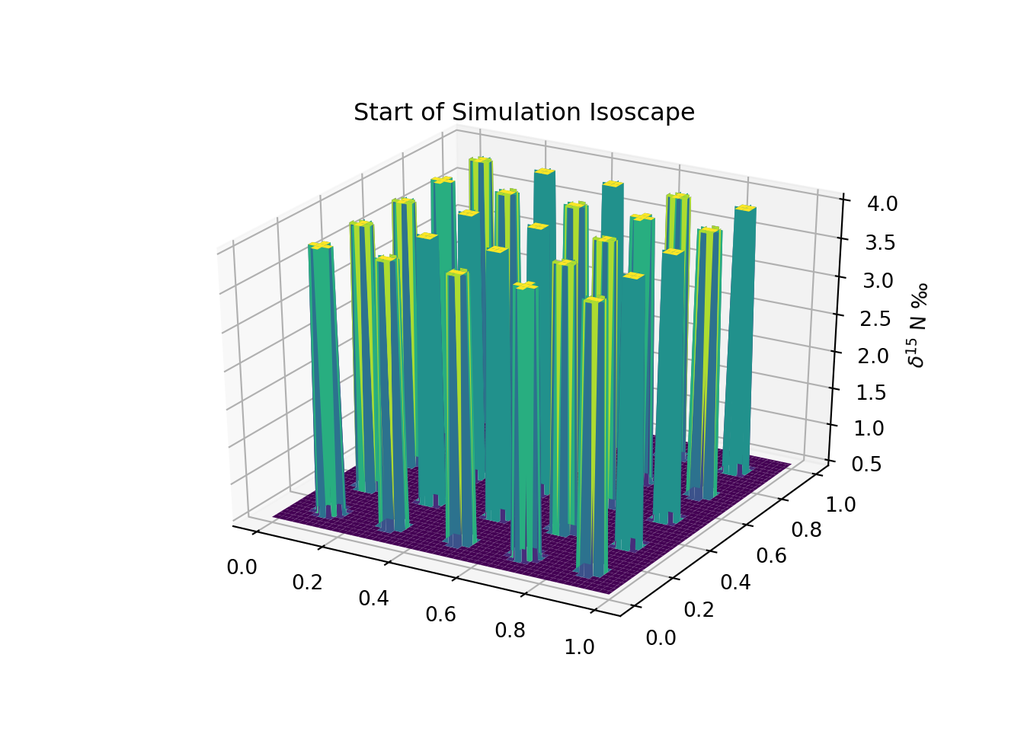

```python
ny, nx = d15_uni_start.shape
xd = np.linspace(0, 1, nx)
yd = np.linspace(0, 1, ny)
xv, yv = np.meshgrid(xd, yd)
p_d15_uni_start = plt.figure()
p_d15_uni_start = p_d15_uni_start.add_subplot(111, projection = '3d')
p_d15_uni_start.plot_surface(xv, yv, d15_uni_start, cmap = 'viridis')
p_d15_uni_start.set_zlabel("$\delta$$^{15}$ N ‰")
p_d15_uni_start.set_title("Start of Simulation Isoscape")
plt.show()
```

View the end of the simulation as an isoscape:

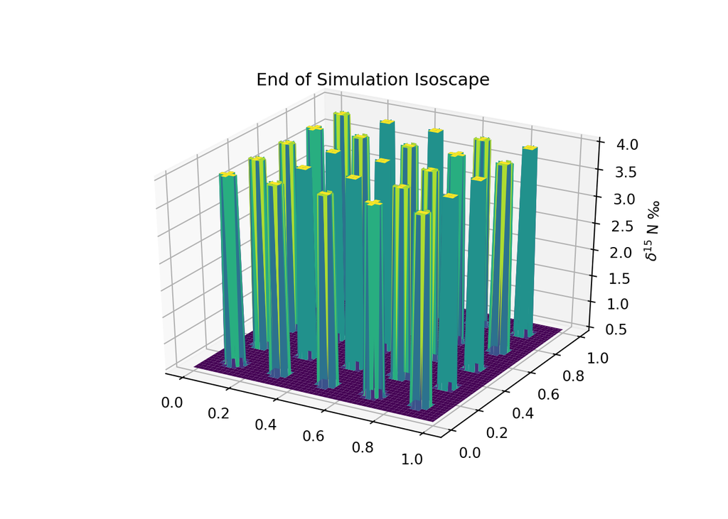

```python
ny, nx = d15_uni_start.shape
xd = np.linspace(0, 1, nx)
yd = np.linspace(0, 1, ny)
xv, yv = np.meshgrid(xd, yd)
p_d15_uni_end = plt.figure()
p_d15_uni_end = p_d15_uni_end.add_subplot(111, projection = '3d')
p_d15_uni_end.plot_surface(xv, yv, d15_uni_end, cmap = 'viridis')
p_d15_uni_end.set_zlabel("$\delta$$^{15}$ N ‰")
p_d15_uni_end.set_title("End of Simulation Isoscape")
plt.show()
```

Wait, aren’t these plots identical? Yes – while the **amount** of food in and outside of the termite mounds has changed, the mean isotopic composition of these areas has not. What **has** changed is the relative abundance of these isotopes in the landscape, as animals have preferentially grazed on the “heavy” Nitrogen areas of the termite mounds. To visualize this, we will weight the isotopic composition of each gridsquare by the amount of food contained within.

```python
d15N_uni_start_average = np.sum(uni_landscape_start * d15_uni_start) / np.sum(uni_landscape_start)
d15N_uni_start_average
```

```
## 1.6815693430656935
```

```python
d15N_uni_end_average = np.sum(uni_landscape_end * d15_uni_end) / np.sum(uni_landscape_end)
d15N_uni_end_average
```

```
## 1.5056647065250581
```

```python
d15N_uni_start_average - d15N_uni_end_average
```

```
## 0.17590463654063537
```

In this simulation we see a decrease in the overall isotopic composition of the landscape by 0.176‰

# Comparison of landscape type

In the original model simulations, agents were released into landscapes with termite mounds spaced in either a **uniformly** or **random** arrangement. How does grazing affect the isoscape?

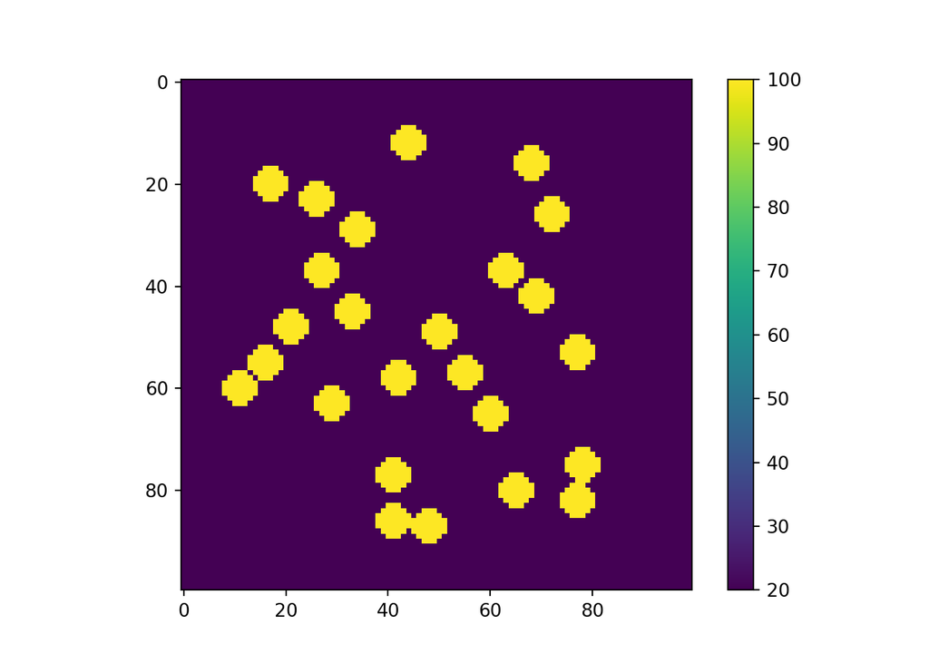

```python
rand_landscape_end = genfromtxt('TeamTermite/dfs/degrades_random/random_200_500_quantity_end.csv', delimiter=",")
rand_landscape_start = genfromtxt('TeamTermite/dfs/degrades_random/random_200_500_quantity_start.csv', delimiter=",")

heatmap2d(rand_landscape_start)
```

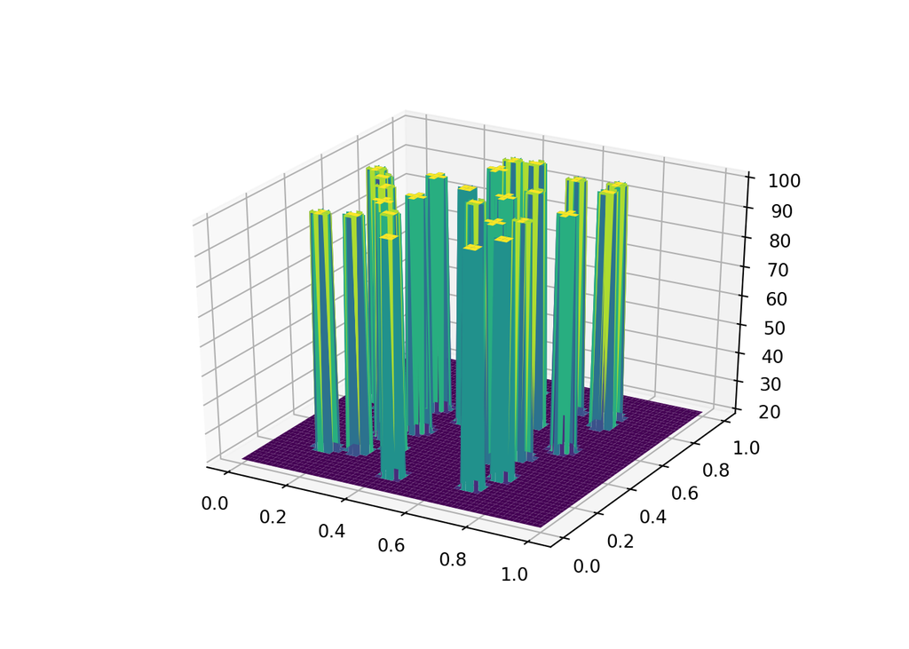

```python
surface3d(rand_landscape_start)
```

Convert landscape to isoscape as done above:

```python
d15_rand_start = rand_landscape_start.copy()
d15_rand_start[d15_rand_start == 100] = 4 # delta 15N in permil
d15_rand_start[d15_rand_start == 20] = 0.5 # delta 15N in permil

d15_rand_end = rand_landscape_start.copy()
d15_rand_end[d15_rand_end == 100] = 4 # delta 15N in permil
d15_rand_end[d15_rand_end == 20] = 0.5 # delta 15N in permil
```

```python
d15N_rand_start_average = np.sum(rand_landscape_start * d15_rand_start) / np.sum(rand_landscape_start)
d15N_rand_start_average
```

```
## 1.6815693430656935
```

```python
d15N_rand_end_average = np.sum(rand_landscape_end * d15_rand_end) / np.sum(rand_landscape_end)
d15N_rand_end_average
```

```
## 1.486180821743969
```

```python
d15N_rand_start_average - d15N_rand_end_average
```

```
## 0.19538852132172457
```

This grazing behavior results in a change in $\delta^{15}N$ of 0.195‰

## Over-grazing scenario

What happens when over-grazing occurs to the point that the landscape structure is nearly destroyed? Let’s consider the scenario where the final food amounts are much further depleted.

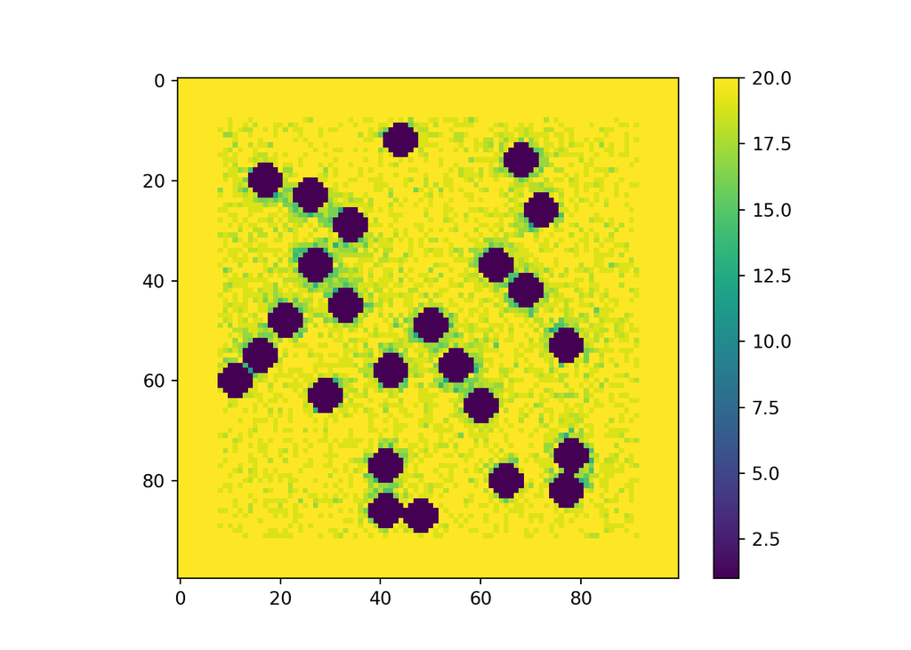

```python
# Generate new numpy arrays to edit
import random
uni_landscape_end_2 = uni_landscape_end.copy()
rand_landscape_end_2 = rand_landscape_end.copy()

# Over-graze the termite mound areas: reduce their plant matter value to a random integer between 1 and 30.
uni_landscape_end_2[uni_landscape_end_2 > 30] = random.randint(1, 30)
rand_landscape_end_2[rand_landscape_end_2 > 30] = random.randint(1, 30)
heatmap2d(rand_landscape_end_2)

# Convert these into isoscapes using the mappings from the previous section
# Starting condition is the same - random landscape
```

```python
d15N_rand_start_average_2 = np.sum(rand_landscape_start * d15_rand_start) / np.sum(rand_landscape_start)
d15N_uni_start_average_2 = np.sum(uni_landscape_start * d15_uni_start) / np.sum(uni_landscape_start)

# End condition is different - random landscape
d15N_rand_end_average_2 = np.sum(rand_landscape_end_2 * d15_rand_end) / np.sum(rand_landscape_end_2)
d15N_uni_end_average_2 = np.sum(uni_landscape_end_2 * d15_uni_end) / np.sum(uni_landscape_end_2)

diff_rand_normal = d15N_rand_start_average - d15N_rand_end_average
diff_uni_normal = d15N_uni_start_average - d15N_uni_end_average
diff_rand_overgraze = d15N_rand_start_average_2 - d15N_rand_end_average_2
diff_uni_overgraze = d15N_uni_start_average_2 - d15N_uni_end_average_2

rand_normal = [d15N_rand_start_average, d15N_rand_end_average]
uni_normal = [d15N_uni_start_average, d15N_uni_end_average]
rand_overgraze = [d15N_rand_start_average_2, d15N_rand_end_average_2]
uni_overgraze = [d15N_uni_start_average_2, d15N_uni_end_average_2]
```

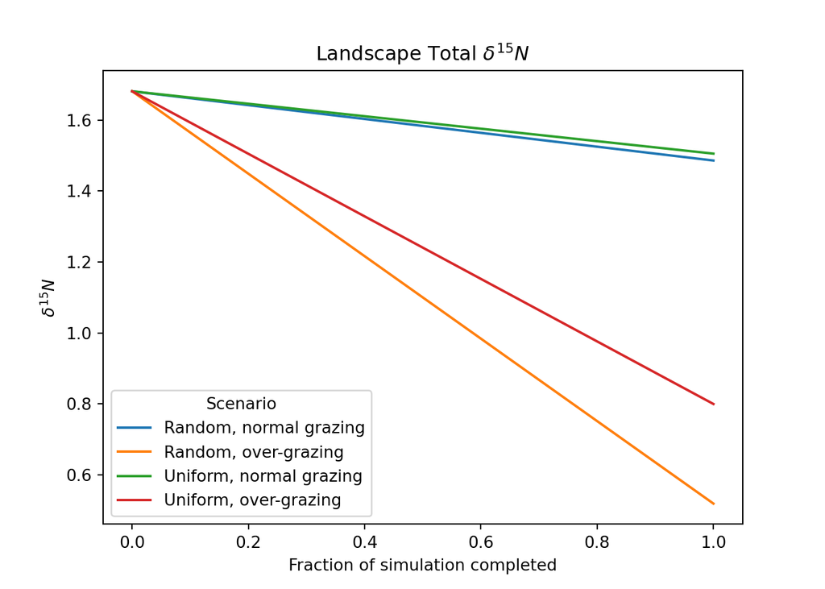

```python
f_iso_data_2 = plt.figure()
a_iso_data_2 = plt.axes()

a_iso_data_2.plot(rand_normal, label = 'Random, normal grazing')
a_iso_data_2.plot(rand_overgraze, label = 'Random, over-grazing')
a_iso_data_2.plot(uni_normal, label = 'Uniform, normal grazing')
a_iso_data_2.plot(uni_overgraze, label = 'Uniform, over-grazing')
a_iso_data_2.legend(title = 'Scenario')
a_iso_data_2.set_title('Landscape Total $\delta^{15}N$')
a_iso_data_2.set_xlabel('Fraction of simulation completed')
a_iso_data_2.set_ylabel('$\delta^{15}N$')
```

# The 15N Natural Abundance Method

First, we define isotopic values in delta notation as such:
$$\delta^{15}N = \frac{R_{sample} - R_{std}}{R_{std}} * 1000 ‰$$
Where R is the ratio of isotope $^{15}N$ “heavy” to $^{14}N$ “light”:
$$R = (^{15}N/^{14}N)$$

The percentage of 15N from the atmosphere out of the total N in a plant sample ($\% N_{dfa}$) is calculated as below:

$$\%N_{dfa} = (\delta^{15}N_0 - \delta^{15}N_t) / (\delta^{15}N_0 - \delta^{15}N_a) \space * 100 \%$$
where $\delta^{15}N_0$ : a non-N2 fixing reference plant, in our case, **Aerva** $\delta^{15}N_t$ : a N2 fixing plant, in our case **Acacia** $\delta^{15}N_a$ : N2 fixing plants in an N-free medium

We can think about the Nitrogen isotopic composition of the **Acacia** tree using a simple mixing model that is a function of proportion $N_2 fixation$:

$$\delta^{15}N_{acacia} = pN_{fix}(\delta^{15}N_{atm} + \Delta^{15}_{assim - atm}) \\
+ (1 - pN_{fix})(\delta^{15}N_{soil} + \Delta^{15}N_{assim-soil})$$

Where:

- $pN_{fix}$ : the proportion of **Acacia** leaf N that is derived from fixation
- $\Delta^{15}N_{assim}$ : isotopic spacing from the source (atmospheric N to plant-available soil N) to leaf tissue.
- $\Delta^{15}N_{assim}$ : an approximation of the actual isotopic differences between the sources and leaf tissue. Values for $\delta^{15}N_{atm}$ and $\delta^{15}N_{soil}$ are the values for atmospheric $N_2$ and soil-derived plant-available N, respectively.

In essence, using mass-balance, the above equation tells us that the N isotopic composition of **Acacia** is equal to the proportion of Nitrogen resulting from fixation *plus* the Nitrogen from non-fixed sources. These source terms are weighted by the isotopic composition of the atmosphere, $\delta^{15}N$, and that of the soil $\delta^{15}N$, respectively. These isotopic compositions are themselves altered by fractionation within their respective systems. The capital delta $\Delta^{15}$ terms refer to the fractionation inherent to Nitrogen fixation (“assim-atm”) and nitrification (“assim-soil”).

We solve for $pN_{fix}$ and simplify the above equation by assuming that $\delta^{15}N_{soil}$ + $\Delta^{15}N_{assim-soil}$ = **Aerva** $\delta^{15}N$ values. By definition, $\delta^{15}N_{atm} = 0 ‰$.

$$pN_{fix} = \frac{\delta^{15}N_{acacia} - \delta^{15}N_{aerva}}
{\Delta^{15}N_{assim-atm} -\delta^{15}N_{aerva}}$$

If we assume a value for $\Delta^{15}N_{assim-atm}$, we can use this equation to estimate pNfix values for each pair of Acacia and Aerva samples. For this model, we will assume $\Delta^{15}N_{assim-atm} = 0‰$ i.e. we assume that there is no fractionation between atmospheric nitrogen and the fixed N pool. In a second scenario, we could consider a kinetic isotope effect of biological nitrogen fixation resulting in a fractionation of -2‰, $\Delta^{15}N_{assim-atm} = -2‰$, as is commonly reported in literature.

What we are left with is the following:

$$pN_{fix} = \frac{\delta^{15}N_{acacia} - \delta^{15}N_{aerva}}
{- \delta^{15}N_{aerva}}$$
### Plotting

As an exmaple, we can use two isotopic values for *Acacia* and *Aerva* and compute that the proportion of Nitrogen sourced from fixation is about 81%.

```r
d15N_acacia_example = + 0.75
d15N_aerva_example = + 4
pNfix_example = (d15N_acacia_example - d15N_aerva_example)/(-d15N_aerva_example)
pNfix_example
```

```
## [1] 0.8125
```

If we assume that $\Delta^{15}N_{assim-atm}$ is -2‰, we observe a different value:

```r
d15N_acacia_example = + 0.75
d15N_aerva_example = + 4
pNfix_example = (d15N_acacia_example - d15N_aerva_example)/(-2 - d15N_aerva_example) # fractionation of -2 permil between atmosphere and fixed N
pNfix_example
```

```
## [1] 0.5416667
```

Switching to python, we can define a function:

```r
nfix <- function(d15N_acacia, d15N_aerva, del_assim_atm = 0) {
  p_N_fix <- (d15N_acacia - d15N_aerva)/(del_assim_atm - d15N_aerva)
  return(p_N_fix)
}
```

```python
def nfix(d15N_acacia, d15N_aerva, del_assim_atm = 0):
  p_N_fix = (d15N_acacia - d15N_aerva)/(del_assim_atm - d15N_aerva)
  return p_N_fix

nfix(0.75, 4)
```

```
## 0.8125
```

Define a vectorized function:

```python
vnfix = np.vectorize(nfix)
```

Apply to our $\delta ^{15}N$ landscape:

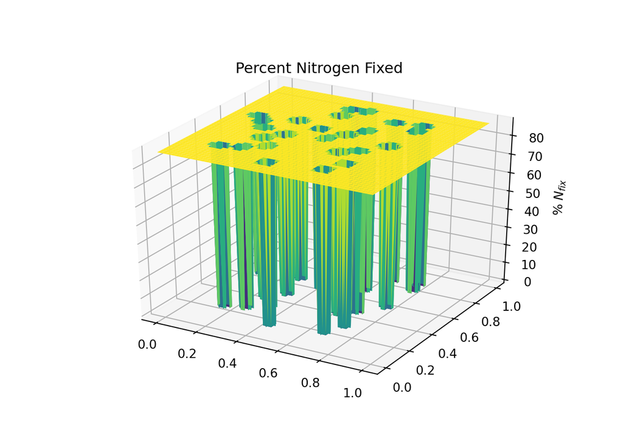

```python
nfix_uni_ls = d15_uni_start.copy()
nfix_uni_ls = vnfix(d15N_acacia = nfix_uni_ls, d15N_aerva = 4)
nfix_uni_ls = nfix_uni_ls*100 # convert to percentage

nfix_rand_ls = d15_rand_start.copy()
nfix_rand_ls = vnfix(d15N_acacia = nfix_rand_ls, d15N_aerva = 4)
nfix_rand_ls = nfix_rand_ls*100 # convert to percentage


f_nfix_rand = plt.figure()
a_nfix_rand = f_nfix_rand.add_subplot(111, projection = '3d')
a_nfix_rand.plot_surface(xv, yv, nfix_rand_ls, cmap = 'viridis')
a_nfix_rand.set_title('Percent Nitrogen Fixed')
a_nfix_rand.set_zlabel('% $N_{fix}$')
plt.show()
```

The fixation landscape assuming that $\Delta ^{15}N_{assim-atm}$ = 0. Because soil $NO_3^-$ is highest in the mounds, *Acacia* trees rely less on Nitrogen derived from $N_2$ fixing bacteria.

# A more complex isoscape

Acacia $\delta^{15}N$ isoscape can be generated. Surface values are derived from the best-fit model for Acacia $\delta^{15}N$ using averages of relative latitude and longitude for the mapped region:

$$log(\delta^{15}N + 1) = 1.2608 - 0.0347(d) + 0.000255(lat) - 6.0308x10^{-7}(long)^2$$
**where** d : distance from mound center lat : relative latitude long : relative longitude

> to be continued